# dataAnalysisR

Roberto Martin Grande

16 de marzo de 2016

```r
library(knitr)
library(reshape)
library(gplots)
library(dplyr)
library(graphics)
```

Abrimos los ficheros de portugues y matematicas

```r
con <- file("./student/student-por.csv","r")
con2 <- file("./student/student-mat.csv","r")
studentPor <- read.csv2(con)
studentMat <- read.csv2(con2)
```

Estudiantes portugues:

```r
kable(head(studentPor[]))
```

| school | sex | age | address | famsize | Pstatus | Medu | Fedu | Mjob | Fjob | reason | guardian | traveltime | studytime | failures | schoolsup | famsup | paid | activities | nursery | higher | internet | romantic | famrel | freetime | goout | Dalc | Walc | health | absences | … |
| --- | --- | --- | --- | --- | --- | --- | --- | --- | --- | --- | --- | --- | --- | --- | --- | --- | --- | --- | --- | --- | --- | --- | --- | --- | --- | --- | --- | --- | --- | --- |
| GP | F | 18 | U | GT3 | A | 4 | 4 | at_home | teacher | course | mother | 2 | 2 | 0 | yes | no | no | no | yes | yes | no | no | 4 | 3 | 4 | 1 | 1 | 3 | 4 | … |
| GP | F | 17 | U | GT3 | T | 1 | 1 | at_home | other | course | father | 1 | 2 | 0 | no | yes | no | no | no | yes | yes | no | 5 | 3 | 3 | 1 | 1 | 3 | 2 | … |
| GP | F | 15 | U | LE3 | T | 1 | 1 | at_home | other | other | mother | 1 | 2 | 0 | yes | no | no | no | yes | yes | yes | no | 4 | 3 | 2 | 2 | 3 | 3 | 6 | … |
| GP | F | 15 | U | GT3 | T | 4 | 2 | health | services | home | mother | 1 | 3 | 0 | no | yes | no | yes | yes | yes | yes | yes | 3 | 2 | 2 | 1 | 1 | 5 | 0 | … |
| GP | F | 16 | U | GT3 | T | 3 | 3 | other | other | home | father | 1 | 2 | 0 | no | yes | no | no | yes | yes | no | no | 4 | 3 | 2 | 1 | 2 | 5 | 0 | … |
| GP | M | 16 | U | LE3 | T | 4 | 3 | services | other | reputation | mother | 1 | 2 | 0 | no | yes | no | yes | yes | yes | yes | no | 5 | 4 | 2 | 1 | 2 | 5 | 6 | … |

Estudiantes matematicas:

```r
kable(head(studentMat[]))
```

| school | sex | age | address | famsize | Pstatus | Medu | Fedu | Mjob | Fjob | reason | guardian | traveltime | studytime | failures | schoolsup | famsup | paid | activities | nursery | higher | internet | romantic | famrel | freetime | goout | Dalc | Walc | health | absences | … |
| --- | --- | --- | --- | --- | --- | --- | --- | --- | --- | --- | --- | --- | --- | --- | --- | --- | --- | --- | --- | --- | --- | --- | --- | --- | --- | --- | --- | --- | --- | --- |
| GP | F | 18 | U | GT3 | A | 4 | 4 | at_home | teacher | course | mother | 2 | 2 | 0 | yes | no | no | no | yes | yes | no | no | 4 | 3 | 4 | 1 | 1 | 3 | 6 | … |
| GP | F | 17 | U | GT3 | T | 1 | 1 | at_home | other | course | father | 1 | 2 | 0 | no | yes | no | no | no | yes | yes | no | 5 | 3 | 3 | 1 | 1 | 3 | 4 | … |
| GP | F | 15 | U | LE3 | T | 1 | 1 | at_home | other | other | mother | 1 | 2 | 3 | yes | no | yes | no | yes | yes | yes | no | 4 | 3 | 2 | 2 | 3 | 3 | 10 | … |
| GP | F | 15 | U | GT3 | T | 4 | 2 | health | services | home | mother | 1 | 3 | 0 | no | yes | yes | yes | yes | yes | yes | yes | 3 | 2 | 2 | 1 | 1 | 5 | 2 | … |
| GP | F | 16 | U | GT3 | T | 3 | 3 | other | other | home | father | 1 | 2 | 0 | no | yes | yes | no | yes | yes | no | no | 4 | 3 | 2 | 1 | 2 | 5 | 4 | … |
| GP | M | 16 | U | LE3 | T | 4 | 3 | services | other | reputation | mother | 1 | 2 | 0 | no | yes | yes | yes | yes | yes | yes | no | 5 | 4 | 2 | 1 | 2 | 5 | 10 | … |

```r
names(studentMat) <- tolower(names(studentMat))
names(studentPor) <- tolower(names(studentPor))
kable(head(studentMat[]))
```

| school | sex | age | address | famsize | pstatus | medu | fedu | mjob | fjob | reason | guardian | traveltime | studytime | failures | schoolsup | famsup | paid | activities | nursery | higher | internet | romantic | famrel | freetime | goout | dalc | walc | health | absences | … |
| --- | --- | --- | --- | --- | --- | --- | --- | --- | --- | --- | --- | --- | --- | --- | --- | --- | --- | --- | --- | --- | --- | --- | --- | --- | --- | --- | --- | --- | --- | --- |
| GP | F | 18 | U | GT3 | A | 4 | 4 | at_home | teacher | course | mother | 2 | 2 | 0 | yes | no | no | no | yes | yes | no | no | 4 | 3 | 4 | 1 | 1 | 3 | 6 | … |
| GP | F | 17 | U | GT3 | T | 1 | 1 | at_home | other | course | father | 1 | 2 | 0 | no | yes | no | no | no | yes | yes | no | 5 | 3 | 3 | 1 | 1 | 3 | 4 | … |
| GP | F | 15 | U | LE3 | T | 1 | 1 | at_home | other | other | mother | 1 | 2 | 3 | yes | no | yes | no | yes | yes | yes | no | 4 | 3 | 2 | 2 | 3 | 3 | 10 | … |
| GP | F | 15 | U | GT3 | T | 4 | 2 | health | services | home | mother | 1 | 3 | 0 | no | yes | yes | yes | yes | yes | yes | yes | 3 | 2 | 2 | 1 | 1 | 5 | 2 | … |
| GP | F | 16 | U | GT3 | T | 3 | 3 | other | other | home | father | 1 | 2 | 0 | no | yes | yes | no | yes | yes | no | no | 4 | 3 | 2 | 1 | 2 | 5 | 4 | … |
| GP | M | 16 | U | LE3 | T | 4 | 3 | services | other | reputation | mother | 1 | 2 | 0 | no | yes | yes | yes | yes | yes | yes | no | 5 | 4 | 2 | 1 | 2 | 5 | 10 | … |

```r
kable(head(studentPor[]))
```

| school | sex | age | address | famsize | pstatus | medu | fedu | mjob | fjob | reason | guardian | traveltime | studytime | failures | schoolsup | famsup | paid | activities | nursery | higher | internet | romantic | famrel | freetime | goout | dalc | walc | health | absences | … |
| --- | --- | --- | --- | --- | --- | --- | --- | --- | --- | --- | --- | --- | --- | --- | --- | --- | --- | --- | --- | --- | --- | --- | --- | --- | --- | --- | --- | --- | --- | --- |
| GP | F | 18 | U | GT3 | A | 4 | 4 | at_home | teacher | course | mother | 2 | 2 | 0 | yes | no | no | no | yes | yes | no | no | 4 | 3 | 4 | 1 | 1 | 3 | 4 | … |
| GP | F | 17 | U | GT3 | T | 1 | 1 | at_home | other | course | father | 1 | 2 | 0 | no | yes | no | no | no | yes | yes | no | 5 | 3 | 3 | 1 | 1 | 3 | 2 | … |
| GP | F | 15 | U | LE3 | T | 1 | 1 | at_home | other | other | mother | 1 | 2 | 0 | yes | no | no | no | yes | yes | yes | no | 4 | 3 | 2 | 2 | 3 | 3 | 6 | … |
| GP | F | 15 | U | GT3 | T | 4 | 2 | health | services | home | mother | 1 | 3 | 0 | no | yes | no | yes | yes | yes | yes | yes | 3 | 2 | 2 | 1 | 1 | 5 | 0 | … |
| GP | F | 16 | U | GT3 | T | 3 | 3 | other | other | home | father | 1 | 2 | 0 | no | yes | no | no | yes | yes | no | no | 4 | 3 | 2 | 1 | 2 | 5 | 0 | … |
| GP | M | 16 | U | LE3 | T | 4 | 3 | services | other | reputation | mother | 1 | 2 | 0 | no | yes | no | yes | yes | yes | yes | no | 5 | 4 | 2 | 1 | 2 | 5 | 6 | … |

Comprobamos si hay underescores en las columas de estudiantes de portugues y matematicas

```r
length(grep("_",studentPor$mjob))
```

```
## [1] 135
```

```r
length(grep("_",studentPor$fjob))
```

```
## [1] 42
```

```r
length(grep("_",studentMat$mjob))
```

```
## [1] 59
```

```r
length(grep("_",studentMat$fjob))
```

```
## [1] 20
```

Como hemos visto que hay algunos datos contienen ’_’ por lo que vamos a quitarlas

```r
studentPor$mjob[1:20]
```

```
##  [1] at_home  at_home  at_home  health   other    services other
##  [8] other    services other    teacher  services health   teacher
## [15] other    health   services other    services health
## Levels: at_home health other services teacher
```

```r
studentPor$mjob <- gsub("_","",studentPor$mjob)
studentPor$fjob <- gsub("_","",studentPor$fjob)
studentPor$mjob[1:20]
```

```
##  [1] "athome"   "athome"   "athome"   "health"   "other"    "services"
##  [7] "other"    "other"    "services" "other"    "teacher"  "services"
## [13] "health"   "teacher"  "other"    "health"   "services" "other"
## [19] "services" "health"
```

```r
studentPor$fjob[1:20]
```

```
##  [1] "teacher"  "other"    "other"    "services" "other"    "other"
##  [7] "other"    "teacher"  "other"    "other"    "health"   "other"
## [13] "services" "other"    "other"    "other"    "services" "other"
## [19] "services" "other"
```

Ahora hacemos lo mismo para los estudiantes de matematicas:

```r
studentMat$mjob[1:20]
```

```
##  [1] at_home  at_home  at_home  health   other    services other
##  [8] other    services other    teacher  services health   teacher
## [15] other    health   services other    services health
## Levels: at_home health other services teacher
```

```r
studentMat$mjob <- gsub("_","",studentMat$mjob)
studentMat$fjob <- gsub("_","",studentMat$fjob)
studentMat$mjob[1:20]
```

```
##  [1] "athome"   "athome"   "athome"   "health"   "other"    "services"
##  [7] "other"    "other"    "services" "other"    "teacher"  "services"
## [13] "health"   "teacher"  "other"    "health"   "services" "other"
## [19] "services" "health"
```

```r
studentMat$fjob[1:20]
```

```
##  [1] "teacher"  "other"    "other"    "services" "other"    "other"
##  [7] "other"    "teacher"  "other"    "other"    "health"   "other"
## [13] "services" "other"    "other"    "other"    "services" "other"
## [19] "services" "other"
```

Volvemos a comprobar si sigue habiendo underscores

```r
length(grep("_",studentPor$mjob))
```

```
## [1] 0
```

```r
length(grep("_",studentPor$fjob))
```

```
## [1] 0
```

```r
length(grep("_",studentMat$mjob))
```

```
## [1] 0
```

```r
length(grep("_",studentMat$fjob))
```

```
## [1] 0
```

Ahora queremos saber que estudiantes tienen las dos asignaturas, para eso hacemos un merge (Con all=FALSE indicamos que solo se unan los alumnos que esten en los dos data.frames). Nos quedaremos unicamente con los alumnos que tenan igual los campos que tenemos en el by.

```r
studentMatPor <- merge(studentMat,studentPor,
                       by=c("school","sex","age",
                            "address","famsize",
                            "pstatus","medu",
                            "fedu","mjob",
                            "fjob","reason",
                            "nursery","internet"),
                       all=FALSE,
                       suffixes=c("mat","por"))

kable(head(studentMatPor[]))
```

| school | sex | age | address | famsize | pstatus | medu | fedu | mjob | fjob | reason | nursery | internet | guardianmat | traveltimemat | studytimemat | failuresmat | schoolsupmat | famsupmat | paidmat | activitiesmat | highermat | romanticmat | famrelmat | freetimemat | gooutmat | dalcmat | walcmat | healthmat | absencesmat | … |
| --- | --- | --- | --- | --- | --- | --- | --- | --- | --- | --- | --- | --- | --- | --- | --- | --- | --- | --- | --- | --- | --- | --- | --- | --- | --- | --- | --- | --- | --- | --- |
| GP | F | 15 | R | GT3 | T | 1 | 1 | athome | other | home | yes | yes | mother | 2 | 4 | 1 | yes | yes | yes | yes | yes | no | 3 | 1 | 2 | 1 | 1 | 1 | 2 | … |
| GP | F | 15 | R | GT3 | T | 1 | 1 | other | other | reputation | no | yes | mother | 1 | 2 | 2 | yes | yes | no | no | yes | yes | 3 | 3 | 4 | 2 | 4 | 5 | 2 | … |
| GP | F | 15 | R | GT3 | T | 2 | 2 | athome | other | reputation | yes | no | mother | 1 | 1 | 0 | yes | yes | yes | yes | yes | no | 4 | 3 | 1 | 1 | 1 | 2 | 8 | … |
| GP | F | 15 | R | GT3 | T | 2 | 4 | services | health | course | yes | yes | mother | 1 | 3 | 0 | yes | yes | yes | yes | yes | no | 4 | 3 | 2 | 1 | 1 | 5 | 2 | … |
| GP | F | 15 | R | GT3 | T | 3 | 3 | services | services | reputation | yes | yes | other | 2 | 3 | 2 | no | yes | yes | yes | yes | yes | 4 | 2 | 1 | 2 | 3 | 3 | 8 | … |
| GP | F | 15 | R | GT3 | T | 3 | 4 | services | health | course | yes | yes | mother | 1 | 3 | 0 | yes | yes | yes | yes | yes | no | 4 | 3 | 2 | 1 | 1 | 5 | 2 | … |

```r
dim(studentMatPor)
```

```
## [1] 382  53
```

Ordenamos los datos de studentMatPor por famsize y por edad:

```r
studentMatPor2 <- studentMatPor[order(
        xtfrm(studentMatPor[,5]),studentMatPor[,3]), ]

studentMatPor2[1:15, 1:5]
```

```
##    school sex age address famsize
## 1      GP   F  15       R     GT3
## 2      GP   F  15       R     GT3
## 3      GP   F  15       R     GT3
## 4      GP   F  15       R     GT3
## 5      GP   F  15       R     GT3
## 6      GP   F  15       R     GT3
## 7      GP   F  15       R     GT3
## 10     GP   F  15       U     GT3
## 11     GP   F  15       U     GT3
## 12     GP   F  15       U     GT3
## 13     GP   F  15       U     GT3
## 14     GP   F  15       U     GT3
## 15     GP   F  15       U     GT3
## 16     GP   F  15       U     GT3
## 17     GP   F  15       U     GT3
```

```r
studentMatPor2$famsize <- relevel(studentMatPor2$famsize,ref="LE3")
studentMatPor2 <- studentMatPor[order(
        xtfrm(studentMatPor[,5]),studentMatPor[,3]), ]

studentMatPor2[1:15, 1:5]
```

```
##    school sex age address famsize
## 1      GP   F  15       R     GT3
## 2      GP   F  15       R     GT3
## 3      GP   F  15       R     GT3
## 4      GP   F  15       R     GT3
## 5      GP   F  15       R     GT3
## 6      GP   F  15       R     GT3
## 7      GP   F  15       R     GT3
## 10     GP   F  15       U     GT3
## 11     GP   F  15       U     GT3
## 12     GP   F  15       U     GT3
## 13     GP   F  15       U     GT3
## 14     GP   F  15       U     GT3
## 15     GP   F  15       U     GT3
## 16     GP   F  15       U     GT3
## 17     GP   F  15       U     GT3
```

Calculamos la nota media del tercer periodo dependiendo del sexo y de si tienen una relación.

```r
mediaRomantic <- cast(studentMat, sex~romantic, mean, value=c("g3"))
mediaRomantic
```

```
##   sex       no       yes
## 1   F 10.55039  9.012658
## 2   M 11.11194 10.415094
```

Gracias a esto, podemos darnos cuenta que tanto los chicos como las chicas que no estan en una relación sacan mejores notas que los que tienen una relación.

Transformando los datos:

Vamos a crear variables. En éste caso vamos a crear una nueva bariable que es techm, ésta variable tendra TRUE si el trabajo de la madre mjob es other o services y sino FALSE.

```r
studentPorTechM <- studentPor
studentPorTechM$techm <- studentPorTechM$mjob %in% c("other","services")
table(studentPorTechM$techm)
```

```
##
## FALSE  TRUE
##   255   394
```

Podemos ver que hay 255 mujeres que no trabajan en other ni en services y 394 que si.

Para calcular la media de los alumnos de matemáticas en el tercer periodo dependiendo del trabajo de sus padres utilizamos las funciones split() para agrupar los trabajos de los padres, y luego la función sapply() para apalicar la función mean(). La función mean lo que hace es calcula la media del tercer periodo de cada grupo de divideFjob: function(x) mean(x$g3)

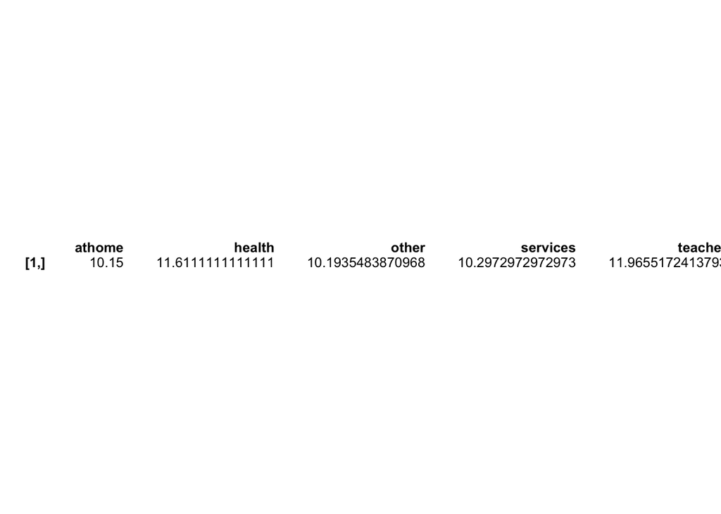

```r
divideFjob <- split(studentMat, studentMat$fjob)
textplot(sapply(divideFjob, function(x) mean(x$g3)), mar=c(0,0,0,0), cex=0.8,fixed.width=TRUE)
```

Para selecionar de un data.frame, en nuestro caso el de estudiantes de matemáticas, las columnas de school y g3 utilizamos select, que está dentro de la librería dplyr:

```r
head(select(studentMat, school, g3))
```

```
##   school g3
## 1     GP  6
## 2     GP  6
## 3     GP 10
## 4     GP 15
## 5     GP 10
## 6     GP 15
```

Podemos utilizar el operador pipe %>%

```r
head(studentMat %>% select(school,g3))
```

```
##   school g3
## 1     GP  6
## 2     GP  6
## 3     GP 10
## 4     GP 15
## 5     GP 10
## 6     GP 15
```

Análisis exploratorio.

Queremos saber si hay algun alumno de matemáticas que haya sacado un 20 en el tercer periodo:

```r
any(studentMat$g3 == 20)
```

```
## [1] TRUE
```

Podemos utilizar varios tipos de plot para representar los datos, por ejemplo con graphics queremos saber el numero de ausencias de los alumnos dependiendo de su nota, y separados por colegio:

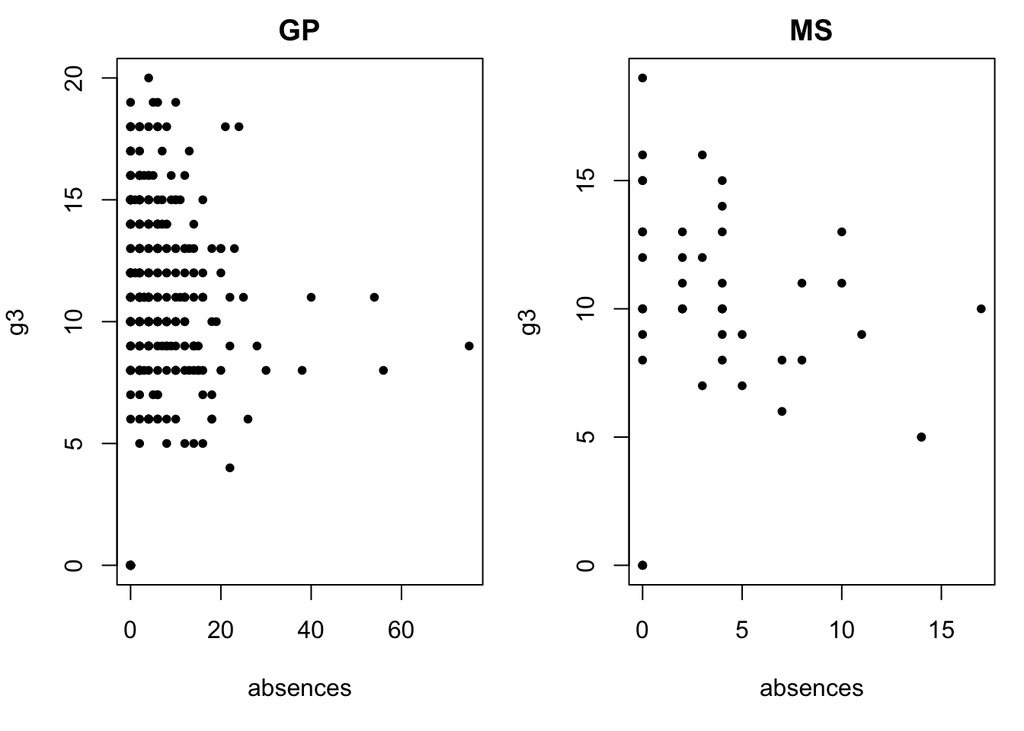

```r
par(mfrow = c(1, 2), mar = c(5, 4, 2, 1))
with(subset(studentMat, school == "GP"),
     plot(absences, g3, main = "GP", pch=20))
with(subset(studentMat, school == "MS"),
     plot(absences, g3, main = "MS", pch=20))
```